# R Notebook

## Some more experiments animating isometric projections

For this piece I use the following package:

```r
library(gganimate)
library(MexBrewer)
library(purrr)
library(sf)
library(showtext)
library(tidyverse)
```

These are the parameters for making a cube:

```r
# Length of side of cube
l <- 1

# Number of lines
steps <- 5
```

These are the steps for creating the line corresponding to the left face of the cube:

```r
# Start and end coordinates of the points for the original line
x_start <- -l * sqrt(3)/2
y_start <- l * 1/2
x_end <- 0
y_end <- 0

# Timing of traces: start and end
timing <- c(0, 1)

# Shifts in the y coordinate to replicate the lines
x_shift <- 0
y_shift <- rep(seq(0, l, l/steps), each = 2)
t_shift <- rep(seq(min(timing), max(timing), (max(timing) - min(timing))/steps), each = 2)

# Direction of line (from left to right: "r", opposite: "l", from bottom to top: "t", from top to bottom: "b" )
h_direction <- "r"
v_direction <- "t"

# Assemble data about lines without the shifts
left_face <- data.frame(pos_x = c(x_start, x_end),
                        pos_y = c(y_start, y_end),
                        x_shift = x_shift,
                        y_shift = y_shift,
                        time = timing,
                        pos_type = c("start", "end"))

# At this point I basically have a bunch of points replicated, but I also have the required coordiante shifts (x_shift = 0 in this case)
left_face <- left_face %>%
  mutate(plot_group = rep(c(1:(n()/2)), each = 2),
         pos_x = pos_x + x_shift,
         pos_y = pos_y + y_shift,
         time = timing + t_shift) %>%
  select(-ends_with("shift"))
```

This is now the right face:

```r
# Start and end coordinates of the points for the original line
x_start <- 0
y_start <- 0
x_end <- l * sqrt(3)/2
y_end <- l * 1/2

# Timing of traces: start and end
timing <- c(1, 2)

# Shifts in the y coordinate to replicate the lines
x_shift <- 0
y_shift <- rep(seq(0, l, l/steps), each = 2)
t_shift <- rep(seq(min(timing), max(timing), (max(timing) - min(timing))/steps), each = 2)

# Direction of line (from left to right: "r", opposite: "l", from bottom to top: "t", from top to bottom: "b" )
h_direction <- "r"
v_direction <- "t"

# Assemble data about lines without the shifts
right_face <- data.frame(pos_x = c(x_start, x_end),
                         pos_y = c(y_start, y_end),
                         x_shift = x_shift,
                         y_shift = y_shift,
                         time = timing,
                         pos_type = c("start", "end"))

# At this point I basically have a bunch of points replicated, but I also have the required coordiante shifts (x_shift = 0 in this case)
right_face <- right_face %>%
  mutate(plot_group = rep(c(1:(n()/2)) + max(left_face$plot_group), each = 2),
         pos_x = pos_x + x_shift,
         pos_y = pos_y + y_shift,
         time = timing + t_shift) %>%
  select(-ends_with("shift"))
```

Now the top face, which is trickier because it requires a shift of the x and y coordinates to make parallel lines that begin an an inclined edge, and also I want the lines to begin on the right and end on the left.

```r
# Start and end coordinates of the points for the original line
x_start <- l * sqrt(3)/2
y_start <- l * (1 + 1/2)
x_end <- 0
y_end <- l

# Timing of traces: start and end
timing <- c(0, 1)

# Shifts in the x, y, and timing coordinates to replicate the lines
x_shift <- rep(seq(0, l * sqrt(3)/2, l * sqrt(3)/(2 * steps)), each = 2)
y_shift <- rep(seq(0, l/2, l/(2 * steps)), each = 2)
t_shift <- rep(seq(max(timing), min(timing), -(max(timing) - min(timing))/steps), each = 2)

# Direction of line (from left to right: "r", opposite: "l", from bottom to top: "t", from top to bottom: "b" )
h_direction <- "r"
v_direction <- "t"

# Assemble data about lines without the shifts
top_face <- data.frame(pos_x = c(x_start, x_end),
                       pos_y = c(y_start, y_end),
                       x_shift = x_shift,
                       y_shift = y_shift,
                       time = timing,
                       pos_type = c("start", "end"))

# At this point I basically have a bunch of points replicated, but I also have the required coordiante shifts (x_shift = 0 in this case)
top_face <- top_face %>%
  mutate(plot_group = rep(c(1:(n()/2)) + max(right_face$plot_group), each = 2),
         pos_x = pos_x - x_shift,
         pos_y = pos_y + y_shift,
         time = timing + t_shift) %>%
  select(-ends_with("shift"))
```

Put together all the faces:

```r
faces <- rbind(data.frame(left_face, face = "left 1"),
               data.frame(right_face, face = "right"),
               data.frame(top_face, face = "top 1"))
```

I hacked this post to plot trajectories over time: https://stackoverflow.com/questions/52671755/gganimate-animate-multiple-paths-based-on-time

```r
dist_per_time = 50

df2 <- faces %>%
  # Add reference to first coordinates for each plot_group
  left_join(by = "plot_group",
            faces %>%
              group_by(plot_group) %>%
              filter(pos_type == "start") %>%
              mutate(pos_x1 = pos_x, pos_y1 = pos_y) %>%
              select(plot_group, pos_x1, pos_y1)
  ) %>%
  left_join(by = c("plot_group", "pos_type"),
            faces %>%
              group_by(plot_group) %>%
              mutate(x_d = (range(pos_x)[1] - range(pos_x)[2]),
                     y_d = (range(pos_y)[1] - range(pos_y)[2]),
                     dist = sqrt(x_d^2 + y_d^2),
                     event_time = time - if_else(pos_type == "start",
                                                 dist / dist_per_time,
                                                 0),
                     event_time = round(event_time, 1)) %>%
              select(plot_group, pos_type, dist, event_time)
  ) %>%
  group_by(plot_group, face) %>%
  mutate(event_time_per_grp = event_time - first(event_time)) %>%
  mutate(event_time_cuml = cumsum(event_time)) %>%
  ungroup()
```

Add faces for a smoother animation:

```r
df3 <- df2 %>%
  rbind(df2,
        df2 %>%
          filter(face == "left 1") %>%
          mutate(event_time_cuml = event_time_cuml + max(event_time_cuml)),
        df2 %>%
          filter(face == "top 1") %>%
          mutate(event_time_cuml = event_time_cuml + max(event_time_cuml)))
```

Plot (check out the difference between plotting df2 and df3):

```r
p <- ggplot(df3, # %>% filter(plot_group == 1 | plot_group == 2 | plot_group == 8 | plot_group == 9),
            aes(pos_x,
                pos_y,
                group = plot_group)) +
  #scale_x_continuous(expand = c(0,0)) + # ,limits = c(0,w)) +
  geom_point(color = "white", size = 0.1) +
   # geom_segment(color = "white",
   #              aes(xend = pos_x1,
   #                  yend  = pos_y1),
   #              size  = 0.75) +
  xlim(c(-l * sqrt(3)/2 - 0.1, l * sqrt(3)/2 + 0.1)) +
  coord_equal() +
  theme_void() +
  theme(panel.background = element_rect(fill = "black")) +
  #transition_time(event_time) +
  transition_reveal(event_time_cuml) + ### EDIT, see above
  shadow_wake(wake_length = 1.0)
```

Animate:

```r
animate(p,
        rewind = TRUE,
        fps = 60,
        duration = 5,
        res = 300,
        height = 2,
        width = 2,
        units = "in")
```

[output not shown]

[output cut: 359 more lines]

[output not shown]

Save animation:

```r
anim_save("animated-negative-space-2.gif")
```

NOTES:

- The time is funky, could I do better by parameterizing position based on time?

## Try something different

These are the parameters for making a cube:

```r
# Length of side of cube
l <- 1

# Number of lines
steps <- 5

# Time intervals for movement
t <- 10
```

Create a function to calculate the position of a point on a straight trajectory, given the starting point, time(s), speed, and angle of movement:

```r
# Create data frame
position <- function(x_start, y_start, t, s, a){
  data.frame(pos_x = x_start + s * t * cos(a),
             pos_y = y_start + s * t * sin(a),
             t = t)
}
```

### Tile 1

Create traces for the top of the cube:

```r
# Start and end coordinates of the original point
x_start <- - l * sqrt(3)/2
y_start <- l * (1 + 1/2)
x_end <- 0
y_end <- l

# Total distance
d <- sqrt((x_end - x_start)^2 + (y_end - y_start)^2)

# Angle
a <- atan((y_end - y_start)/(x_end - x_start))

# Start time
time_start <- 0

# End time
time_end <- time_start + d/s

# Time increments
ts <- seq(time_start, time_end, length.out = 10) - time_start

# Shifts in the x, y, t coordinates to replicate the origin point
x_shift <- seq(0, l * sqrt(3)/2, length.out = steps) * ifelse((x_end - x_start) < 0, -1, 1)
y_shift <- seq(0, l/2, length.out = steps)
t_shift <- 0 #rep(seq(min(timing), max(timing), (max(timing) - min(timing))/steps))

# Calculate position
trace_top <- map2_dfr(x_start + x_shift,
                      y_start + y_shift,
                      .f = ~position(.x,
                                     .y,
                                     ts,
                                     s,
                                     a),
                      .id = "plot_group") %>%
  #mutate(plot_group = as.character(as.numeric(plot_group) + max(as.numeric(trace_1$plot_group))),
  mutate(t = t + time_start,
         plot_group = as.numeric(plot_group))
```

Create traces for the right face of the cube:

```r
# Start and end coordinates of the original point
x_start <- 0
y_start <- l
x_end <- 0
y_end <- 0

# Total distance
d <- sqrt((x_end - x_start)^2 + (y_end - y_start)^2)

# Angle
a <- atan((y_end - y_start)/(x_end - x_start))

# Start time
time_start <- max(trace_top$t)

# End time
time_end <- time_start + d/s

# Time increments
ts <- seq(time_start, time_end, length.out = 10) - time_start

# Shifts in the x, y, t coordinates to replicate the origin point
x_shift <- seq(0, l * sqrt(3)/2, length.out = steps) * ifelse((x_end - x_start) < 0, -1, 1)
y_shift <- seq(0, l/2, length.out = steps)
t_shift <- 0 #rep(seq(min(timing), max(timing), (max(timing) - min(timing))/steps))

# Calculate position
trace_rf <- map2_dfr(x_start + x_shift,
                     y_start + y_shift,
                     .f = ~position(.x,
                                    .y,
                                    ts,
                                    s,
                                    a),
                     .id = "plot_group") %>%
  #mutate(plot_group = as.character(as.numeric(plot_group) + max(as.numeric(trace_1$plot_group))),
  mutate(t = t + time_start,
         plot_group = as.numeric(plot_group))
```

### Assemble Tile 1

Put together two faces:

```r
tile_1 <- rbind(trace_top,
                trace_rf)
```

Plot these traces:

```r
ggplot(tile_1 %>%
         mutate((plot_group = as.character(plot_group))),
       aes(pos_x,
           pos_y,
           group = plot_group)) +
  geom_point(color = "white", size = 0.1) +
  # geom_segment(color = "white",
  #              aes(xend = pos_x1,
  #                  yend  = pos_y1),
  #              size  = 0.75) +
  xlim(c(-l * sqrt(3)/2 - 0.1, l * sqrt(3)/2 + 0.1)) +
  coord_equal() +
  theme_void() +
  theme(panel.background = element_rect(fill = "black")) +
  transition_time(t) +
  shadow_wake(wake_length = 1.0)
```

[output not shown]

[output cut: 137 more lines]

[output not shown]

### Make copy of this tile

Move everything to the horizontally and vertically:

```r
x_shift <- l * sqrt(3)/2
y_shift <- -l * (1 + 1/2)

tiles <- rbind(tile_1,
               tile_1 %>%
                 mutate(pos_x = pos_x + x_shift,
                        pos_y = pos_y + y_shift,
                        plot_group = plot_group + max(plot_group)))
```

Plot these traces:

```r
ggplot(tiles %>%
         mutate(plot_group = as.character(plot_group)),
       aes(pos_x,
           pos_y,
           group = plot_group)) +
  geom_point(color = "white", size = 0.1) +
  # geom_segment(color = "white",
  #              aes(xend = pos_x1,
  #                  yend  = pos_y1),
  #              size  = 0.75) +
  #xlim(c(-l * sqrt(3)/2 - 0.1, l * sqrt(3)/2 + 0.1)) +
  coord_equal() +
  theme_void() +
  theme(panel.background = element_rect(fill = "black")) +
  transition_time(t) +
  shadow_wake(wake_length = 0.9)
```

[output not shown]

[output cut: 137 more lines]

[output not shown]

### Tile 2

Create traces for the right/back face of the cube:

```r
# Start and end coordinates of the original point
x_start <- 0
y_start <- 2 * l
x_end <- 0
y_end <- l

# Total distance
d <- sqrt((x_end - x_start)^2 + (y_end - y_start)^2)

# Angle
a <- atan((y_end - y_start)/(x_end - x_start))

# Start time
time_start <- 0

# End time
time_end <- time_start + d/s

# Time increments
ts <- seq(time_start, time_end, length.out = 10)

# Shifts in the x, y, t coordinates to replicate the origin point
x_shift <- seq(0, l * sqrt(3)/2, length.out = steps) * ifelse((x_end - x_start) < 0, -1, 1)
y_shift <- seq(0, l/2, length.out = steps)* ifelse((y_end - y_start) < 0, -1, 1)
t_shift <- 0 #rep(seq(min(timing), max(timing), (max(timing) - min(timing))/steps))

# Calculate position
trace_rb <- map2_dfr(x_start + x_shift,
                     y_start + y_shift,
                     .f = ~position(.x,
                                    .y,
                                    ts,
                                    s,
                                    a),
                     .id = "plot_group") %>%
  mutate(plot_group = as.numeric(plot_group))
```

```r
# Start and end coordinates of the original point
x_start <- 0
y_start <- l
x_end <- -l * sqrt(3)/2
y_end <- l/2

# Total distance
d <- sqrt((x_end - x_start)^2 + (y_end - y_start)^2)

# Angle
a <- atan((y_end - y_start)/(x_end - x_start)) + pi

# Start time
time_start <- max(trace_rb$t)

# End time
time_end <- time_start + d/s

# Time increments
ts <- seq(time_start, time_end, length.out = 10) - time_start

# Shifts in the x, y, t coordinates to replicate the origin point
x_shift <- seq(0, l * sqrt(3)/2, length.out = steps)
y_shift <- -seq(0, l/2, length.out = steps)
t_shift <- 0 #rep(seq(min(timing), max(timing), (max(timing) - min(timing))/steps))

# Calculate position
trace_bottom <- map2_dfr(x_start + x_shift,
                     y_start + y_shift,
                     .f = ~position(.x,
                                    .y,
                                    ts,
                                    s,
                                    a),
                     .id = "plot_group") %>%
  #mutate(plot_group = as.character(as.numeric(plot_group) + max(as.numeric(trace_1$plot_group))),
  mutate(t = t + time_start,
         plot_group = as.numeric(plot_group))
```

### Assemble Tile 2

Put together two faces:

```r
tile_2 <- rbind(trace_rb,
                trace_bottom)
```

Plot these traces:

```r
ggplot(tile_2,
       aes(pos_x,
           pos_y,
           group = plot_group)) +
  geom_point(color = "white", size = 0.1) +
  # geom_segment(color = "white",
  #              aes(xend = pos_x1,
  #                  yend  = pos_y1),
  #              size  = 0.75) +
  xlim(c(-l * sqrt(3)/2 - 0.1, l * sqrt(3)/2 + 0.1)) +
  coord_equal() +
  theme_void() +
  theme(panel.background = element_rect(fill = "black")) +
  transition_time(t) +
  shadow_wake(wake_length = 1.0)
```

[output not shown]

[output cut: 136 more lines]

[output not shown]

### Make mosaic

Move everything horizontally and vertically:

```r
x_shift <- l * sqrt(3)/2
y_shift <- l * (1 + 1/2)

mosaic <- rbind(tile_1 %>%
                  mutate(tile = 0),
                tile_1 %>%
                 mutate(pos_x = pos_x - x_shift,
                        pos_y = pos_y - y_shift,
                        tile = 1),
                tile_1 %>%
                 mutate(pos_x = pos_x - 2 * x_shift,
                        pos_y = pos_y - 2 * y_shift,
                        tile = 2),
                tile_1 %>%
                 mutate(pos_x = pos_x + 2 * x_shift,
                        pos_y = pos_y - 2 * y_shift,
                        tile = 3),
                tile_2 %>%
                  mutate(pos_x = pos_x - 2 * x_shift,
                         pos_y = pos_y,
                         tile = 4),
                tile_2 %>%
                  mutate(pos_x = pos_x + 2 * x_shift,
                         pos_y = pos_y,
                         tile = 5),
                tile_2 %>%
                  mutate(pos_x = pos_x + x_shift,
                         pos_y = pos_y - y_shift,
                         tile = 6),
                tile_2 %>%
                  mutate(pos_x = pos_x,
                         pos_y = pos_y - 2 * y_shift,
                         tile = 7)) %>%
  mutate(plot_group = plot_group + (steps* tile))
```

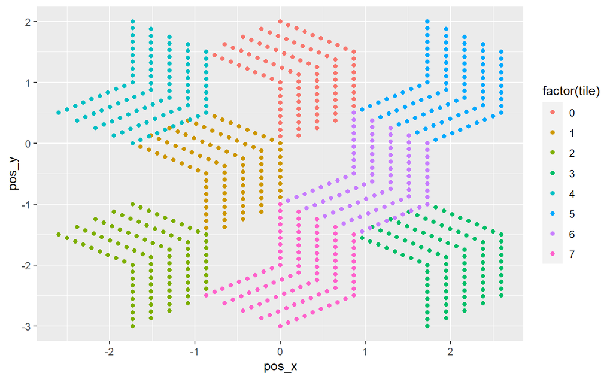

```r
ggplot(mosaic, aes(pos_x, pos_y, color = factor(tile))) + geom_point()
```

Animate the mosaic:

```r
ggplot(mosaic,
       aes(pos_x,
           pos_y,
           group = plot_group)) +
  geom_point(color = "white", size = 0.1) +
  # geom_segment(color = "white",
  #              aes(xend = pos_x1,
  #                  yend  = pos_y1),
  #              size  = 0.75) +
  #xlim(c(-l * sqrt(3)/2 - 0.1, l * sqrt(3)/2 + 0.1)) +
  coord_equal() +
  theme_void() +
  theme(panel.background = element_rect(fill = "black")) +
  transition_time(t) +
  shadow_wake(wake_length = 1.1)
```

[output not shown]

[output cut: 141 more lines]

[output not shown]

Save animation:

```r
anim_save("animated-negative-space-3.gif")
```

Now it’s finally doing what I want it to do, but it takes a lot of manual adjustments, there must be a way to convert this into a fully procedural process, so that I can introduce some randomness without it breaking apart due to the need of manual adjustments.

Something to explore more.